# Initiation to R software Session V

Master AMSE 1st year, 2019

## Loops and tests

## Loops and tests

R has instructions that are similar to that of C language.

Main instructions:

- `for (... in ...) {}`: runs code in `{}` for some values.
- `while (...) {}`: runs code in `{}` while a condition is true.
- `if (...) {} else {}`: runs code in `{}` conditionally.

In most cases, loops can be avoided by **vectorization** and the use of **simpler** and less **time-consuming** functions (e.g `apply()`).

If objects are created in a loop, always **define them first**.

## Loops and tests: example 1

*Aim*: create a vector that equals 0 if x equals 3, 1 elsewhere, then add this vector to x.

```r
# Try this example !
# Solution 1: Loop
system.time({
  x = sample(1:100, 10, rep = T)
  y = numeric(length(x))
  for(i in 1:length(x)) {
    if (x[i] == 3) y[i] = 0
    else y[i] = 1
  }
})

# Solution 2: Vectorization
system.time({
  x = sample(1:100, 10, rep = T)
})
```

[output not shown]

[output not shown]

## Loops and tests: example 2

*Aim*: sum on the columns of a matrix.

```r
# Try this example !
# Solution 1: Loop
system.time({
  M = matrix(sample(1:10, 20, rep = T), 5, 4)
  SM = numeric(length(ncol(M)))
  for (j in 1:ncol(M)) {
    SM[j] = sum(M[,j])
  }
})

# Solution 2: Function
system.time({
  M = matrix(sample(1:10, 20, rep = T), 5, 4)
  SM = apply(M, 2, sum)
})
```

## R programming

## Write a program in R

A program in R is a **sequence of instructions**, saved in a text file (a script in format `.txt` or `.R`).

A program can be run using the function `source()`.

Useful when you want to perform the same task several times.

## Write a program in R: example

*Aim*: plot the same graphic several times, for 3 different species

```r
# Solution 1:
layout(matrix(1:3,3,1))
data(iris)
data = iris[iris$Species == "setosa",]
plot(data$Sepal.Length, data$Sepal.Width,
          xlab = "Sepal Length", ylab = "Sepal Width")
title("setosa")
data = iris[iris$Species == "versicolor",]
plot(data$Sepal.Length, data$Sepal.Width,
          xlab = "Sepal Length", ylab = "Sepal Width")
title("versicolor")
data = iris[iris$Species == "virginica",]
plot(data$Sepal.Length, data$Sepal.Width,
          xlab = "Sepal Length", ylab = "Sepal Width")
title("virginica")
```

## Write a program in R: example

*Aim*: plot the same graphic several times, for 3 different species

```r
# Solution 2: save the program in file "mySpecies.R"
# The following commands should be saved in a script
layout(matrix(1:3,3,1))
data(iris)
species = unique(iris$Species)
for (i in 1:length(species)) {
  data = iris[ iris$Species == species[i],]
  plot(data$Sepal.Length, data$Sepal.Width,
          xlab = "Sepal Length", ylab = "Sepal Width")
  title(species[i])
}
# Then, run the program saved in a script
source("mySpecies.R")
```

## Write a program in R: example

*Aim*: plot the same graphic several times, for 3 different species

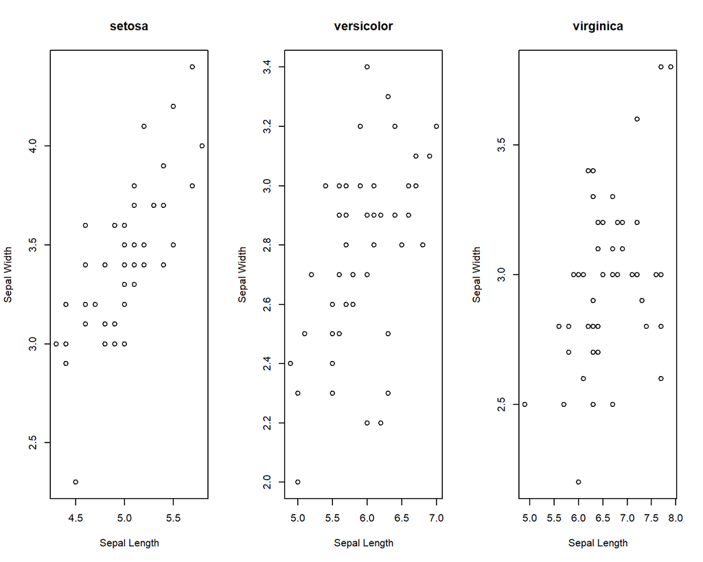

## Functions

## Functions

To use a program as much as we want, by changing its parameters at will, we can **write a function**. The written functions will have the same properties as those from R packages.

A function is an R program with **variable parameters** given in the `function()` instruction that initiates function writing.

Syntax: `function_name = function(p1, p2, p3, ...) {}`

The instructions of the function are written in `{}`.

## Functions

To run, a function must be loaded in memory, this can be done in several ways:

- Type the commands on the keyboard
- Copy/paste them to an R editor
- save the function in a R file and load it with the command `source()`

If you want the function to be loaded when R starts, you can save it in a file with the extension `.Rda`, which will be loaded in memory if located in the working directory (use `getwd()`).

## Functions

```r
# Solution 3: write a function saved in "myFun.R"
# The following lines should be saved in the script
myFun = function(specie, data) {
  data = iris[iris$Species == specie,]
  plot(data$Sepal.Length, data$Sepal.Width,
          xlab = "Sepal Length", ylab = "Sepal Width")
  title(specie)
}
# Run the function
layout(matrix(1:3,3,1))
source("myFun.R")
myFun("setosa", iris)
myFun("versicolor", iris)
myFun("virginica", iris)
```

## Basic functions

## Basic mathematical functions

| function_name | description |
| --- | --- |
| sum(x) | Sum of the elements of x |
| prod(x) | Product of the elements of x |
| max(x), min(x) | Maximum, minimum of the elements of |
| which.max(x) | Returns the index of the maximum of the elements of x |
| which.min(x) | Returns the index of the minimum of the elements of x |
| range(x) | Similar to c(min(x), max(x)) |
| mean(x) | Mean of the elements of x |
| median(x) | Median of the elements of x |

## Other basic mathematical functions

| function_name | description |
| --- | --- |
| var(x) | Variance of the elements of x |
| cov(x) | Covariance matrix if x is a matrix |
| cor(x) | Correlation matrix of x if x is a matrix or a data.frame |
| sd(x) | Standard deviation of the elements of x |
| round(x,n) | Rounds the elements of x to n decimals |
| rev(x) | Reverse the order of the elements of x |
| sort(x) | Sort the elements of x in ascending order |
| rank(x) | Rank the elements of x |
| scale(x) | Scale (center and reduce) x |

## … and other basic mathematical functions…

| function_name | description |
| --- | --- |
| pmin(x,y,…) | A vector whose element i is the minimum of x[i] and y[i] |
| cumsum(x) | A vector whose element i is the sum of x[i] and y[i] |
| cumprod() | Similar as cumsum() with product |
| cummin() | Similar as cumsum() with minimum |
| cummax() | Similar as cumsum() with maximum |
| match(x,y) | Vector of same length as x with elements of x that are in y |
| choose(x,k) | Binomial coefficient |
| na.omit() | Remove observations with missing values |
| na.fail() | Returns an error message if x contains at least one NA |

## … and others

| function_name | description |
| --- | --- |
| unique() | Returns a similar object without duplicates |
| table() | Returns table of counts of the values of x |
| subset() | Returns a selection of x based on criteria |
| sample(x,n) | Random sampling of x of size n, without replacement |